# Practical Machine Learning Course Project

Kriti Amatya

June 1, 2016

# Summary

Using devices such as Jawbone Up, Nike FuelBand, and Fitbit it is now possible to collect a large amount of data about personal activity relatively inexpensively. These type of devices are part of the quantified self movement - a group of enthusiasts who take measurements about themselves regularly to improve their health, to find patterns in their behavior, or because they are tech geeks. One thing that people regularly do is quantify how much of a particular activity they do, but they rarely quantify how well they do it. In this project, our goal will be to use data from accelerometers on the belt, forearm, arm, and dumbell of 6 participants.

# Read the data

Read both training and testing data which are in the current folder.

```r
training_data <- read.csv("pml-training.csv", na.strings=c("#DIV/0!"," ", "", "NA", "NAs", "NULL"))
testing_data <- read.csv("pml-testing.csv", na.strings=c("#DIV/0!"," ", "", "NA", "NAs", "NULL"))
```

# Clean the data

We need to drop columns with NAs, drop highly correlated variables and drop variables with 0 (or approx to 0) variance. The results are hidden as they take a very long space.

```r
str(training_data)
```

```
## 'data.frame':    19622 obs. of  160 variables:
##  $ X                       : int  1 2 3 4 5 6 7 8 9 10 ...
##  $ user_name               : Factor w/ 6 levels "adelmo","carlitos",..: 2 2 2 2 2 2 2 2 2 2 ...
##  $ raw_timestamp_part_1    : int  1323084231 1323084231 1323084231 1323084232 1323084232 1323084232 1323084232 1323084232 1323084232 1323084232 ...
##  $ raw_timestamp_part_2    : int  788290 808298 820366 120339 196328 304277 368296 440390 484323 484434 ...
##  $ cvtd_timestamp          : Factor w/ 20 levels "02/12/2011 13:32",..: 9 9 9 9 9 9 9 9 9 9 ...
##  $ new_window              : Factor w/ 2 levels "no","yes": 1 1 1 1 1 1 1 1 1 1 ...
##  $ num_window              : int  11 11 11 12 12 12 12 12 12 12 ...
##  $ roll_belt               : num  1.41 1.41 1.42 1.48 1.48 1.45 1.42 1.42 1.43 1.45 ...
##  $ pitch_belt              : num  8.07 8.07 8.07 8.05 8.07 8.06 8.09 8.13 8.16 8.17 ...
##  $ yaw_belt                : num  -94.4 -94.4 -94.4 -94.4 -94.4 -94.4 -94.4 -94.4 -94.4 -94.4 ...
##  $ total_accel_belt        : int  3 3 3 3 3 3 3 3 3 3 ...
##  $ kurtosis_roll_belt      : num  NA NA NA NA NA NA NA NA NA NA ...
##  $ kurtosis_picth_belt     : num  NA NA NA NA NA NA NA NA NA NA ...
##  $ kurtosis_yaw_belt       : logi  NA NA NA NA NA NA ...
```

[output cut: 86 more lines]

```r
cleantraining <- training_data[, -which(names(training_data) %in% c("X", "user_name", "raw_timestamp_part_1", "raw_timestamp_part_2", "cvtd_timestamp", "new_window", "num_window"))]
# This drops columns with NAs
cleantraining = cleantraining[, colSums(is.na(cleantraining)) == 0]
zerovariance =nearZeroVar(cleantraining[sapply(cleantraining, is.numeric)], saveMetrics=TRUE)
# To remove 0 or near to 0 variance variables
cleantraining = cleantraining[, zerovariance[, 'nzv'] == 0]
correlationmatrix <- cor(na.omit(cleantraining[sapply(cleantraining, is.numeric)]))
dim(correlationmatrix)
```

```
## [1] 52 52
```

```r
correlationmatrixdegreesoffreedom <- expand.grid(row = 1:52, col = 1:52)
# This returns the correlation matrix in matrix format
correlationmatrixdegreesoffreedom$correlation <- as.vector(correlationmatrix)
removehighcorrelation <- findCorrelation(correlationmatrix, cutoff = .7, verbose = TRUE)
```

```
## Compare row 10  and column  1 with corr  0.992
##   Means:  0.27 vs 0.168 so flagging column 10
## Compare row 1  and column  9 with corr  0.925
##   Means:  0.25 vs 0.164 so flagging column 1
## Compare row 9  and column  22 with corr  0.722
##   Means:  0.233 vs 0.161 so flagging column 9
## Compare row 22  and column  4 with corr  0.759
##   Means:  0.224 vs 0.158 so flagging column 22
## Compare row 4  and column  3 with corr  0.762
##   Means:  0.2 vs 0.155 so flagging column 4
## Compare row 3  and column  8 with corr  0.708
##   Means:  0.2 vs 0.153 so flagging column 3
## Compare row 36  and column  29 with corr  0.849
##   Means:  0.257 vs 0.151 so flagging column 36
## Compare row 8  and column  2 with corr  0.966
##   Means:  0.229 vs 0.146 so flagging column 8
## Compare row 2  and column  11 with corr  0.884
##   Means:  0.212 vs 0.143 so flagging column 2
## Compare row 37  and column  38 with corr  0.769
##   Means:  0.198 vs 0.139 so flagging column 37
## Compare row 35  and column  30 with corr  0.773
##   Means:  0.195 vs 0.137 so flagging column 35
## Compare row 38  and column  5 with corr  0.781
##   Means:  0.177 vs 0.134 so flagging column 38
## Compare row 21  and column  24 with corr  0.814
##   Means:  0.176 vs 0.133 so flagging column 21
## Compare row 34  and column  28 with corr  0.808
##   Means:  0.176 vs 0.13 so flagging column 34
## Compare row 23  and column  26 with corr  0.779
##   Means:  0.137 vs 0.129 so flagging column 23
## Compare row 25  and column  24 with corr  0.792
##   Means:  0.145 vs 0.128 so flagging column 25
## Compare row 12  and column  13 with corr  0.779
##   Means:  0.122 vs 0.127 so flagging column 13
## Compare row 48  and column  51 with corr  0.772
##   Means:  0.145 vs 0.127 so flagging column 48
## Compare row 19  and column  18 with corr  0.918
##   Means:  0.095 vs 0.127 so flagging column 18
## Compare row 46  and column  45 with corr  0.846
##   Means:  0.131 vs 0.129 so flagging column 46
## Compare row 45  and column  31 with corr  0.71
##   Means:  0.098 vs 0.129 so flagging column 31
## Compare row 45  and column  33 with corr  0.716
##   Means:  0.078 vs 0.132 so flagging column 33
## All correlations <= 0.7
```

```r
# This removes highly correlated variables (in psychometric theory .7+ correlation is a high correlation)
cleantraining <- cleantraining[, -removehighcorrelation]

for(i in c(8:ncol(cleantraining)-1)) {cleantraining[,i] = as.numeric(as.character(cleantraining[,i]))}
# Some columns were blank, hence are dropped. I will use a set that only includes complete columns. I also remove user name, timestamps and windows to have a light data set.
for(i in c(8:ncol(testing_data)-1)) {testing_data[,i] = as.numeric(as.character(testing_data[,i]))}

featureset <- colnames(cleantraining[colSums(is.na(cleantraining)) == 0])[-(1:7)]
modeldata <- cleantraining[featureset]
#now we have the model data built from our feature set.
featureset
```

```
##  [1] "yaw_arm"              "total_accel_arm"      "gyros_arm_y"
##  [4] "gyros_arm_z"          "magnet_arm_x"         "magnet_arm_z"
##  [7] "roll_dumbbell"        "pitch_dumbbell"       "yaw_dumbbell"
## [10] "total_accel_dumbbell" "gyros_dumbbell_y"     "magnet_dumbbell_z"
## [13] "roll_forearm"         "pitch_forearm"        "yaw_forearm"
## [16] "total_accel_forearm"  "gyros_forearm_x"      "gyros_forearm_y"
## [19] "accel_forearm_x"      "accel_forearm_z"      "magnet_forearm_x"
## [22] "magnet_forearm_y"     "magnet_forearm_z"     "classe"
```

# Model

We need to split the sample in two samples. 60% for training and 40% for testing is the usual.

```r
idx <- createDataPartition(modeldata$classe, p=0.6, list=FALSE )
training <- modeldata[idx,]
testing <- modeldata[-idx,]
```

A predictive model is fitted using Random Forest algorithm. Highly correlated variables were already removed but still this algorithm is robust to correlated covariates and outliers. A 5 fold cross validation is used.

```r
control <- trainControl(method="cv", 5)
model <- train(classe ~ ., data=training, method="rf", trControl=control, ntree=250)
model
```

```
## Random Forest
##
## 11776 samples
##    23 predictor
##     5 classes: 'A', 'B', 'C', 'D', 'E'
##
## No pre-processing
## Resampling: Cross-Validated (5 fold)
## Summary of sample sizes: 9420, 9420, 9421, 9421, 9422
## Resampling results across tuning parameters:
##
##   mtry  Accuracy   Kappa
##    2    0.9697693  0.9617393
##   12    0.9671374  0.9584094
##   23    0.9550798  0.9431564
##
## Accuracy was used to select the optimal model using  the largest value.
## The final value used for the model was mtry = 2.
```

The performance of the model is estimated on the validation data set.

```r
predict <- predict(model, testing)
confusionMatrix(testing$classe, predict)
```

```
## Confusion Matrix and Statistics
##
##           Reference
## Prediction    A    B    C    D    E
##          A 2226    3    0    2    1
##          B   34 1470   11    1    2
##          C    1   20 1343    3    1
##          D    7    0   48 1224    7
##          E    4   18    1   13 1406
##
## Overall Statistics
##
##                Accuracy : 0.9774
##                  95% CI : (0.9739, 0.9806)
##     No Information Rate : 0.2896
##     P-Value [Acc > NIR] : < 2.2e-16
##
##                   Kappa : 0.9714
##  Mcnemar's Test P-Value : 6.823e-15
##
## Statistics by Class:
##
##                      Class: A Class: B Class: C Class: D Class: E
## Sensitivity            0.9798   0.9729   0.9572   0.9847   0.9922
## Specificity            0.9989   0.9924   0.9961   0.9906   0.9944
## Pos Pred Value         0.9973   0.9684   0.9817   0.9518   0.9750
## Neg Pred Value         0.9918   0.9935   0.9907   0.9971   0.9983
## Prevalence             0.2896   0.1926   0.1788   0.1584   0.1806
## Detection Rate         0.2837   0.1874   0.1712   0.1560   0.1792
## Detection Prevalence   0.2845   0.1935   0.1744   0.1639   0.1838
## Balanced Accuracy      0.9893   0.9826   0.9767   0.9877   0.9933
```

```r
accuracy <- postResample(predict, testing$classe)
accuracy
```

```
##  Accuracy     Kappa
## 0.9774407 0.9714449
```

# Predictions

```r
result <- predict(model, training[, -length(names(training))])
```

# Tree

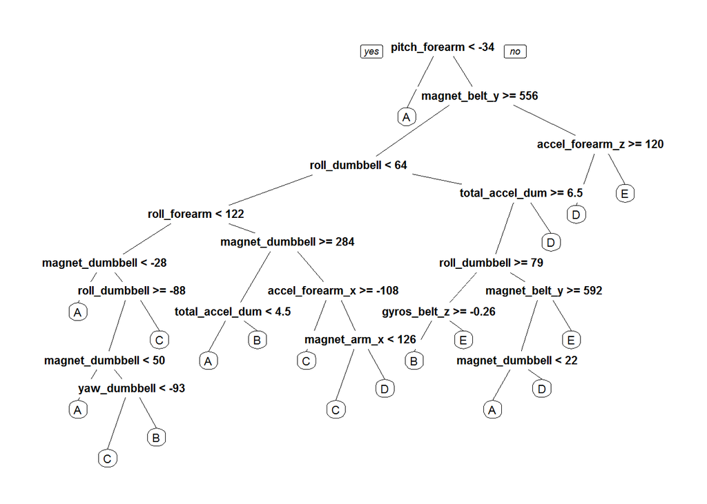

```r
treeModel <- rpart(classe ~ ., data=cleantraining, method="class")
prp(treeModel)
```

# The Question’s answer

```r
pml_write_files = function(x){
  n = length(x)
  for(i in 1:n){
    filename = paste0("Prediction_file_",i,".txt")
    write.table(x[i],file=filename,quote=FALSE,row.names=FALSE,col.names=FALSE)
  }
}

testing_data <- testing_data[featureset[featureset!='classe']]
answers <- predict(model, newdata=testing_data)
answers
```

```
##  [1] B A B A A E D B A A B C B A E E A B B B
## Levels: A B C D E
```

```r
pml_write_files(answers)
```